# Projet - SY09

## Sélection de variable

```r
data$Class <- as.numeric(levels(data$Class))[data$Class]
summary(lm(Class~.,data=data))
```

```
Call:
lm(formula = Class ~ ., data = data)

Residuals:
     Min       1Q   Median       3Q      Max
-1.04515 -0.00162  0.00003  0.00096  1.00069

Coefficients:
              Estimate Std. Error  t value Pr(>|t|)
(Intercept)  1.519e-03  5.488e-05   27.678  < 2e-16 ***
V1          -1.848e-03  3.864e-05  -47.824  < 2e-16 ***
V2           3.110e-03  8.052e-05   38.617  < 2e-16 ***
V3          -4.842e-03  4.699e-05 -103.036  < 2e-16 ***
V4           3.637e-03  4.109e-05   88.516  < 2e-16 ***
V5          -2.194e-03  7.389e-05  -29.688  < 2e-16 ***
V6          -1.687e-03  5.437e-05  -31.025  < 2e-16 ***
V7          -7.001e-03  8.535e-05  -82.028  < 2e-16 ***
V8           8.300e-04  4.823e-05   17.209  < 2e-16 ***
V9          -3.496e-03  4.909e-05  -71.212  < 2e-16 ***
V10         -7.874e-03  5.290e-05 -148.834  < 2e-16 ***
V11          6.136e-03  5.193e-05  118.152  < 2e-16 ***
V12         -1.058e-02  5.306e-05 -199.448  < 2e-16 ***
V13         -1.544e-04  5.317e-05   -2.904 0.003684 **
V14         -1.279e-02  5.594e-05 -228.634  < 2e-16 ***
V15         -1.587e-04  5.802e-05   -2.735 0.006240 **
V16         -9.172e-03  6.103e-05 -150.297  < 2e-16 ***
V17         -1.584e-02  6.250e-05 -253.397  < 2e-16 ***
V18         -5.637e-03  6.411e-05  -87.927  < 2e-16 ***
V19          1.989e-03  6.708e-05   29.659  < 2e-16 ***
V20         -1.419e-04  1.311e-04   -1.082 0.279196
V21          1.843e-03  8.130e-05   22.673  < 2e-16 ***
V22          2.988e-04  7.603e-05    3.929 8.53e-05 ***
V23          2.140e-04  1.103e-04    1.939 0.052457 .
V24         -4.903e-04  8.743e-05   -5.608 2.05e-08 ***
V25          4.379e-04  1.046e-04    4.188 2.82e-05 ***
V26          4.103e-04  1.100e-04    3.728 0.000193 ***
V27          1.611e-03  1.428e-04   11.282  < 2e-16 ***
V28          1.116e-03  1.799e-04    6.202 5.57e-10 ***
Amount       1.580e-03  1.243e-04   12.705  < 2e-16 ***
---
Signif. codes:  0 '***' 0.001 '**' 0.01 '*' 0.05 '.' 0.1 ' ' 1

Residual standard error: 0.02796 on 280012 degrees of freedom
Multiple R-squared:  0.5191,    Adjusted R-squared:  0.519
F-statistic: 1.042e+04 on 29 and 280012 DF,  p-value: < 2.2e-16
```

```r
data$Class <- as.factor(data$Class)
```

[figure not shown]

```r
regsubset <- regsubsets(Class~., data=data, method = "exhaustive", nvmax = 30)
plot(regsubset, scale = "bic")
```

```r
res.sum <- summary(regsubset)
data.frame(BIC = which.min(res.sum$bic))
```

| BIC |
| --- |
| 25 |

```r
names(data)[summary(regsubset)$which[which.min(summary(regsubset)$bic),-1]]
```

```
 [1] "V1"     "V2"     "V3"     "V4"     "V5"     "V6"     "V7"     "V8"     "V9"     "V10"
[11] "V11"    "V12"    "V14"    "V16"    "V17"    "V18"    "V19"    "V21"    "V22"    "V24"
[21] "V25"    "V26"    "V27"    "V28"    "Amount" "Class"
```

Cette sélection permet de mettre en avant 25 prédicteurs principaux. On constate que cela produit le meme résultat que la sélection par la p-value.

Nous allons par la suite appliquer à ces sélections des modèles différents afin de prédire de manière précise les transactions frauduleuses. Nous avons en premier le modèle global, en deuxième celui produit par la variance expliquée des composantes principales et le dernier par sélection de varibale (regsubset).

```r
Formula <- c(
  Class~.,
  Class~.-c(V20,V21,V22,V23,V24,V25,V26,V27,V28),
  Class~.-c(V13,V15,V20,V23)
)
```

# Solution au problème de déséquilibre de classe

Le problème principal de ce jeu de donnée est de créer un jeu de donnée qui représente au mieux les caractéristiques des transactions valides et frauduleuses. En effet, le déséquilibre du jeu de donnée de base va fortement influencer le modèle dans le choix des modèles : il ne prédira quasiment jamais de fraude. Il aura plus de 99% de précision dans ce cas et on considérera que la précision de notre modèle est bon alors qu’il ne prédit en aucun cas la détection de fraude.

Ainsi, nous divisons le jeu de données de trois manières différentes: partitionnement direct, sous-échantillonnage et sur-échantillonnage.

## Partitionnement direct

Dans cette méthode, nous divisons directement le jeu de données en un ensemble d’apprentissage et un ensemble de test selon un ratio de 0,7 à 0,3. Il en résulte que les échantillons positifs et négatifs de l’ensemble d’apprentissage et de l’ensemble de test restent extrêmement déséquilibrés.

```
class0 : class1 dans l'ensemble d'apprentissage est  195725 : 304
class0 : class1 dans l'ensemble de test est  83861 : 152
```

## Sous-échantillonnage

Pour les deux types de données gravement inégales dans l’ensemble de données, parmi les échantillons les plus abondants, sélectionnez de manière aléatoire le même nombre d’échantillons que le plus petit nombre d’échantillons et, finalement, formez le même nombre d’échantillons positifs et négatifs.

```
Après sous-échantillonnag :
class0 : class1 dans l'ensemble d'apprentissage est  323 : 315
class0 : class1 dans l'ensemble de test est  133 : 141
```

## Sur-échantillonnage

Générez le complément du plus petit nombre d’échantillons dans l’échantillon pour correspondre au plus grand. L’algorithme couramment utilisé est SMOTE.

```
Après sur-échantillonnag :
class0 : class1 dans l'ensemble d'apprentissage est  3187 : 3308
class0 : class1 dans l'ensemble de test est  1373 : 1500
```

## Représentation graphique

Il est impossible de se représenter un espace à 30 dimensions et hormis la représentation des composantes principales, nous n’avons pas pu visualiser si les classes sont réellement séparées. De plus la représentation de l’ACP ne prend pas en compte ni le montant ni le temps. Pour cela nous allons utiliser l’algorithme t-SNE qui est une technique de réduction de dimension pour la visualisation de données. L’algorithme t-SNE tente de trouver une configuration optimale selon un critère pour respecter les proximités entre points : deux points qui sont proches dans l’espace d’origine devront être proches dans l’espace de faible dimension.

```r
## Data
data.tsne <- under_data
## Colors for plotting
colors = rainbow(length(unique(data.tsne$Class)))
names(colors) = unique(data.tsne$Class)
## Executing the algorithm on curated data
tsne <- Rtsne(data.tsne, dims = 2, perplexity=50, verbose=TRUE, max_iter = 1000, check_duplicates = FALSE)
```

[output not shown]

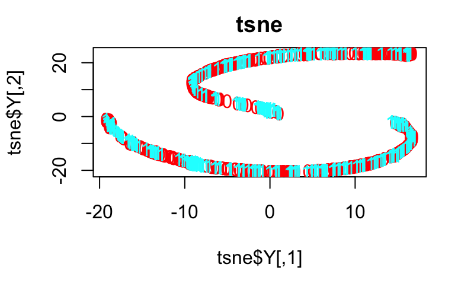

```r
## Plotting
plot(tsne$Y, t='n', main="tsne")
text(tsne$Y, labels=data.tsne$Class, col=colors[data.tsne$Class])
```

```
La matrice de confusion pour KNN_under
               true_class
predicted_class   0   1
              0 132  24
              1   1 117
La matrice de confusion pour KNN_over
               true_class
predicted_class    0    1
              0 1333  107
              1   40 1393
```

[figure not shown]

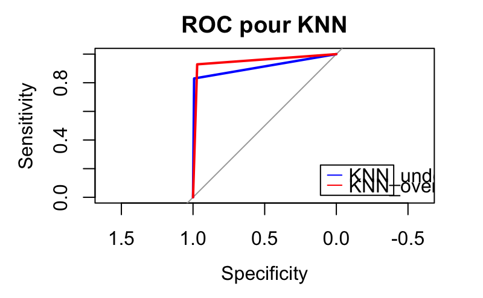

|  | method | TPrate | FPrate | precision | recall | accuracy | F1score | AUC |
| --- | --- | --- | --- | --- | --- | --- | --- | --- |
| 1 | KNN_under | 0.8297872 | 0.007518797 | 0.9915254 | 0.8297872 | 0.9087591 | 0.9034749 | 0.9111342 |
| 2 | KNN_over | 0.9286667 | 0.029133285 | 0.9720865 | 0.9286667 | 0.9488340 | 0.9498807 | 0.9497667 |

## Classification supervisé

### LDA

```
La matrice de confusion pour LDA
               true_class
predicted_class     0     1
              0 83846    34
              1    15   118
La matrice de confusion pour LDA-under
               true_class
predicted_class   0   1
              0 130  23
              1   3 118
La matrice de confusion pour LDA-over
               true_class
predicted_class    0    1
              0 1342  216
              1   31 1284
```

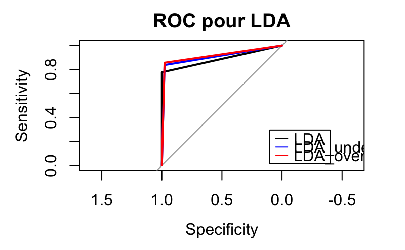

|  | method | TPrate | FPrate | precision | recall | accuracy | F1score | AUC |
| --- | --- | --- | --- | --- | --- | --- | --- | --- |
| 1 | KNN_under | 0.8297872 | 0.0075187970 | 0.9915254 | 0.8297872 | 0.9087591 | 0.9034749 | 0.9111342 |
| 2 | KNN_over | 0.9286667 | 0.0291332848 | 0.9720865 | 0.9286667 | 0.9488340 | 0.9498807 | 0.9497667 |
| 3 | LDA | 0.7763158 | 0.0001788674 | 0.8872180 | 0.7763158 | 0.9994168 | 0.8280702 | 0.8880685 |
| 4 | LDA-under | 0.8368794 | 0.0225563910 | 0.9752066 | 0.8368794 | 0.9051095 | 0.9007634 | 0.9071615 |
| 5 | LDA-over | 0.8560000 | 0.0225782957 | 0.9764259 | 0.8560000 | 0.9140271 | 0.9122558 | 0.9167109 |

### QDA

```
La matrice de confusion pour QDA
               true_class
predicted_class     0     1
              0 81752    11
              1  2109   141
La matrice de confusion pour QDA-under
               true_class
predicted_class   0   1
              0 126  10
              1   7 131
La matrice de confusion pour QDA-over
               true_class
predicted_class    0    1
              0 1329  163
              1   44 1337
```

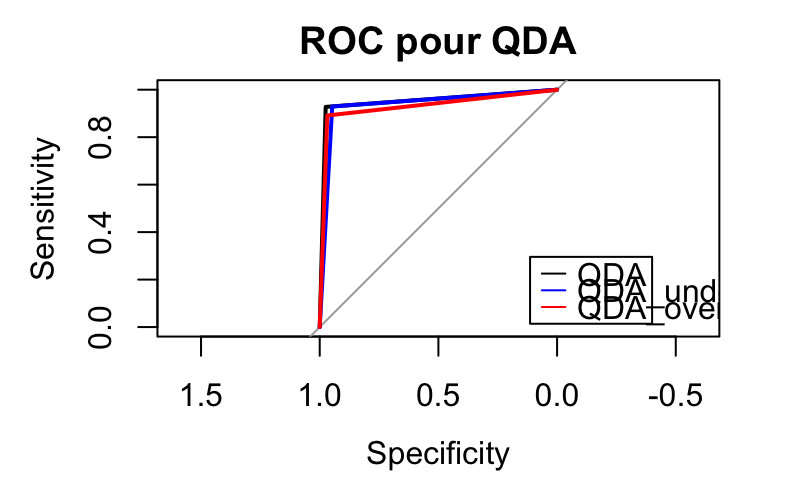

|  | method | TPrate | FPrate | precision | recall | accuracy | F1score | AUC |
| --- | --- | --- | --- | --- | --- | --- | --- | --- |
| 1 | KNN_under | 0.8297872 | 0.0075187970 | 0.99152542 | 0.8297872 | 0.9087591 | 0.9034749 | 0.9111342 |
| 2 | KNN_over | 0.9286667 | 0.0291332848 | 0.97208653 | 0.9286667 | 0.9488340 | 0.9498807 | 0.9497667 |
| 3 | LDA | 0.7763158 | 0.0001788674 | 0.88721805 | 0.7763158 | 0.9994168 | 0.8280702 | 0.8880685 |
| 4 | LDA-under | 0.8368794 | 0.0225563910 | 0.97520661 | 0.8368794 | 0.9051095 | 0.9007634 | 0.9071615 |
| 5 | LDA-over | 0.8560000 | 0.0225782957 | 0.97642586 | 0.8560000 | 0.9140271 | 0.9122558 | 0.9167109 |
| 6 | QDA | 0.9276316 | 0.0251487581 | 0.06266667 | 0.9276316 | 0.9747658 | 0.1174022 | 0.9512414 |
| 7 | QDA-under | 0.9290780 | 0.0526315789 | 0.94927536 | 0.9290780 | 0.9379562 | 0.9390681 | 0.9382232 |
| 8 | QDA-over | 0.8913333 | 0.0320466133 | 0.96813903 | 0.8913333 | 0.9279499 | 0.9281499 | 0.9296434 |

### Naïve bayésienne

```
La matrice de confusion pour NB
               true_class
predicted_class     0     1
              0 82140    18
              1  1721   134
La matrice de confusion pour NB-under
               true_class
predicted_class   0   1
              0 130  19
              1   3 122
La matrice de confusion pour NB-over
               true_class
predicted_class    0    1
              0 1337  219
              1   36 1281
```

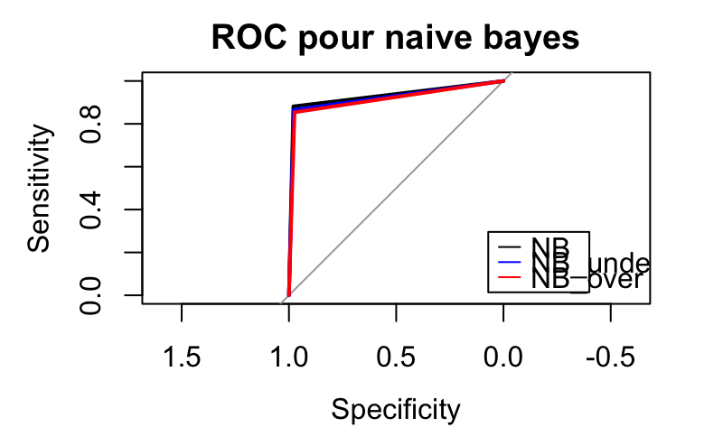

|  | method | TPrate | FPrate | precision | recall | accuracy | F1score | AUC |
| --- | --- | --- | --- | --- | --- | --- | --- | --- |
| 1 | KNN_under | 0.8297872 | 0.0075187970 | 0.99152542 | 0.8297872 | 0.9087591 | 0.9034749 | 0.9111342 |
| 2 | KNN_over | 0.9286667 | 0.0291332848 | 0.97208653 | 0.9286667 | 0.9488340 | 0.9498807 | 0.9497667 |
| 3 | LDA | 0.7763158 | 0.0001788674 | 0.88721805 | 0.7763158 | 0.9994168 | 0.8280702 | 0.8880685 |
| 4 | LDA-under | 0.8368794 | 0.0225563910 | 0.97520661 | 0.8368794 | 0.9051095 | 0.9007634 | 0.9071615 |
| 5 | LDA-over | 0.8560000 | 0.0225782957 | 0.97642586 | 0.8560000 | 0.9140271 | 0.9122558 | 0.9167109 |
| 6 | QDA | 0.9276316 | 0.0251487581 | 0.06266667 | 0.9276316 | 0.9747658 | 0.1174022 | 0.9512414 |
| 7 | QDA-under | 0.9290780 | 0.0526315789 | 0.94927536 | 0.9290780 | 0.9379562 | 0.9390681 | 0.9382232 |
| 8 | QDA-over | 0.8913333 | 0.0320466133 | 0.96813903 | 0.8913333 | 0.9279499 | 0.9281499 | 0.9296434 |
| 9 | NB | 0.8815789 | 0.0205220544 | 0.07223720 | 0.8815789 | 0.9793008 | 0.1335326 | 0.9305284 |
| 10 | NB-under | 0.8652482 | 0.0225563910 | 0.97600000 | 0.8652482 | 0.9197080 | 0.9172932 | 0.9213459 |

[output cut: 1 more lines]

### Logistique regression

```
La matrice de confusion pour Logistic regression
               true_class
predicted_class     0     1
              0 83853    61
              1     8    91
La matrice de confusion pour Logistic regression under
               true_class
predicted_class   0   1
              0 130  12
              1   3 129
La matrice de confusion pour Logistic regression over
               true_class
predicted_class    0    1
              0 1329  120
              1   44 1380
```

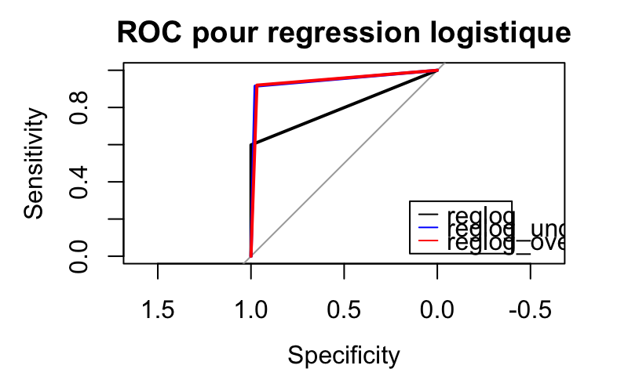

|  | method | TPrate | FPrate | precision | recall | accuracy | F1score | AUC |
| --- | --- | --- | --- | --- | --- | --- | --- | --- |
| 1 | KNN_under | 0.8297872 | 7.518797e-03 | 0.99152542 | 0.8297872 | 0.9087591 | 0.9034749 | 0.9111342 |
| 2 | KNN_over | 0.9286667 | 2.913328e-02 | 0.97208653 | 0.9286667 | 0.9488340 | 0.9498807 | 0.9497667 |
| 3 | LDA | 0.7763158 | 1.788674e-04 | 0.88721805 | 0.7763158 | 0.9994168 | 0.8280702 | 0.8880685 |
| 4 | LDA-under | 0.8368794 | 2.255639e-02 | 0.97520661 | 0.8368794 | 0.9051095 | 0.9007634 | 0.9071615 |
| 5 | LDA-over | 0.8560000 | 2.257830e-02 | 0.97642586 | 0.8560000 | 0.9140271 | 0.9122558 | 0.9167109 |
| 6 | QDA | 0.9276316 | 2.514876e-02 | 0.06266667 | 0.9276316 | 0.9747658 | 0.1174022 | 0.9512414 |
| 7 | QDA-under | 0.9290780 | 5.263158e-02 | 0.94927536 | 0.9290780 | 0.9379562 | 0.9390681 | 0.9382232 |
| 8 | QDA-over | 0.8913333 | 3.204661e-02 | 0.96813903 | 0.8913333 | 0.9279499 | 0.9281499 | 0.9296434 |
| 9 | NB | 0.8815789 | 2.052205e-02 | 0.07223720 | 0.8815789 | 0.9793008 | 0.1335326 | 0.9305284 |
| 10 | NB-under | 0.8652482 | 2.255639e-02 | 0.97600000 | 0.8652482 | 0.9197080 | 0.9172932 | 0.9213459 |

[output cut: 4 more lines]

### SVM

```
La matrice de confusion pour SVM-under
               true_class
predicted_class   0   1
              0 132  45
              1   1  96
La matrice de confusion pour SVM-over
               true_class
predicted_class    0    1
              0 1352  125
              1   21 1375
```

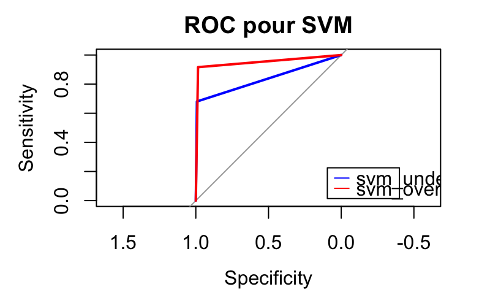

```r
source("fonctions.R")
init_performance("Performances")
SVM(train_under_x,train_under_y,test_under_x,test_under_y,train_over_x,train_over_y,test_over_x,test_over_y)
```

```r
Performances
```

|  | method | TPrate | FPrate | precision | recall | accuracy | F1score | AUC |
| --- | --- | --- | --- | --- | --- | --- | --- | --- |
| 1 | SVM-under | 0.6808511 | 0.007518797 | 0.9896907 | 0.6808511 | 0.8321168 | 0.8067227 | 0.8366661 |
| 2 | SVM-over | 0.9166667 | 0.015294975 | 0.9849570 | 0.9166667 | 0.9491820 | 0.9495856 | 0.9506858 |

### Arbre de décision

```r
#voir les fonctions dans le fichier arbre.R
```

## Test

Pour mieux évaluer les performances de chaque modèle, nous avons testé chaque modèle sur un ensemble de test non équilibré. En comparant les performances de chaque algorithme sur cet ensemble de tests, nous pouvons connaître dans une certaine mesure la capacité de généralisation du modèle, car le modèle obtenu avec l’ensemble de formation en sur-échantillonnage risque d’être sur-apprentissage.

```r
init_performance("Performances_test")
pred <- predict(lda.model,newdata = test_data)
Performances_test <- add_Performance("LDA",pred$class,test_y,Performance = Performances_test)
```

```
La matrice de confusion pour LDA
               true_class
predicted_class     0     1
              0 83846    34
              1    15   118
```

```r
pred <- predict(lda.under.model,newdata = test_data)
Performances_test <- add_Performance("LDA-under",pred$class,test_y,Performance = Performances_test)
```

```
La matrice de confusion pour LDA-under
               true_class
predicted_class     0     1
              0 82309    18
              1  1552   134
```

```r
pred <- predict(lda.over.model,newdata = test_data)
Performances_test <- add_Performance("LDA-over",pred$class,test_y,Performance = Performances_test)
```

```
La matrice de confusion pour LDA-over
               true_class
predicted_class     0     1
              0 82216    15
              1  1645   137
```

```r
pred <- predict(qda.model,newdata = test_data)
Performances_test <- add_Performance("QDA",pred$class,test_y,Performance = Performances_test)
```

```
La matrice de confusion pour QDA
               true_class
predicted_class     0     1
              0 81752    11
              1  2109   141
```

```r
pred <- predict(qda.under.model,newdata = test_data)
Performances_test <- add_Performance("QDA-under",pred$class,test_y,Performance = Performances_test)
```

```
La matrice de confusion pour QDA-under
               true_class
predicted_class     0     1
              0 78476     7
              1  5385   145
```

```r
pred <- predict(qda.over.model,newdata = test_data)
Performances_test <- add_Performance("QDA-over",pred$class,test_y,Performance = Performances_test)
```

```
La matrice de confusion pour QDA-over
               true_class
predicted_class     0     1
              0 80764    10
              1  3097   142
```

```r
pred <- predict(nb.model,newdata = test_data)
Performances_test <- add_Performance("NB",pred,test_y,Performance = Performances_test)
```

```
La matrice de confusion pour NB
               true_class
predicted_class     0     1
              0 82140    18
              1  1721   134
```

```r
pred <- predict(nb.under.model,newdata = test_data)
Performances_test <- add_Performance("NB-under",pred,test_y,Performance = Performances_test)
```

```
La matrice de confusion pour NB-under
               true_class
predicted_class     0     1
              0 81563    14
              1  2298   138
```

```r
pred <- predict(nb.over.model,newdata = test_data)
Performances_test <- add_Performance("NB-over",pred,test_y,Performance = Performances_test)
```

```
La matrice de confusion pour NB-over
               true_class
predicted_class     0     1
              0 81656    13
              1  2205   139
```

```r
pred <- predict(logreg.model,newdata = test_data)
pred[pred>0.5] = 1
pred[pred<=0.5] = 0
Performances_test <- add_Performance("LogReg",pred,test_y,Performance = Performances_test)
```

```
La matrice de confusion pour LogReg
               true_class
predicted_class     0     1
              0 83854    66
              1     7    86
```

```r
pred <- predict(logreg.under.model,newdata = test_data)
pred[pred>0.5] = 1
pred[pred<=0.5] = 0
Performances_test <- add_Performance("LogReg-under",pred,test_y,Performance = Performances_test)
```

```
La matrice de confusion pour LogReg-under
               true_class
predicted_class     0     1
              0 80293     8
              1  3568   144
```

```r
pred <- predict(logreg.over.model,newdata = test_data)
pred[pred>0.5] = 1
pred[pred<=0.5] = 0
Performances_test <- add_Performance("LogReg-over",pred,test_y,Performance = Performances_test)
```

```
La matrice de confusion pour LogReg-over
               true_class
predicted_class     0     1
              0 81987     8
              1  1874   144
```

```r
#pred <- predict(svm.model,newdata = test_x)
#Performances_test <- add_Performance("SVM",pred,test_y,Performance = Performances_test)
pred <- predict(svm.under.model,newdata = test_x)
Performances_test <- add_Performance("SVM-under",pred,test_y,Performance = Performances_test)
```

```
La matrice de confusion pour SVM-under
               true_class
predicted_class     0     1
              0 83339    35
              1   522   117
```

```r
pred <- predict(svm.over.model,newdata = test_x)
Performances_test <- add_Performance("SVM-over",pred,test_y,Performance = Performances_test)
```

```
La matrice de confusion pour SVM-over
               true_class
predicted_class     0     1
              0 83000     8
              1   861   144
```

```r
#pred <- predict(tree.model,newdata = test_data,type = "class")
#Performances_test <- add_Performance("DT",pred,test_y,Performance = Performances_test)
#pred <- predict(tree.under.model,newdata = test_data,type = "class")
#Performances_test <- add_Performance("DT-under",pred,test_y,Performance = Performances_test)
#pred <- predict(tree.over.model,newdata = test_data,type = "class")
#Performances_test <- add_Performance("DT-over",pred,test_y,Performance = Performances_test)
#pred <- predict(bagging.model, newdata=test_x)
#Performances_test <- add_Performance("Bagging",pred,test_y,Performance = Performances_test)
#pred <- predict(bagging.under.model, newdata=test_x)
#Performances_test <- add_Performance("Bagging-under",pred,test_y,Performance = Performances_test)
#pred <- predict(bagging.over.model, newdata=test_x)
#Performances_test <- add_Performance("Bagging-over",pred,test_y,Performance = Performances_test)
#pred <- predict(RF.model, newdata=test_x)
#Performances_test <- add_Performance("RF",pred,test_y,Performance = Performances_test)
#pred <- predict(RF.under.model, newdata=test_x)
#Performances_test <- add_Performance("RF-under",pred,test_y,Performance = Performances_test)
#pred <- predict(bagging.over.model, newdata=test_x)
#Performances_test <- add_Performance("RF-over",pred,test_y,Performance = Performances_test)
rm(pred)
print(Performances_test)
```

|  | method | TPrate | FPrate | precision | recall | accuracy | F1score | AUC |
| --- | --- | --- | --- | --- | --- | --- | --- | --- |
| 1 | LDA | 0.7763158 | 1.788674e-04 | 0.88721805 | 0.7763158 | 0.9994168 | 0.82807018 | NA |
| 2 | LDA-under | 0.8815789 | 1.850681e-02 | 0.07947805 | 0.8815789 | 0.9813124 | 0.14581066 | NA |
| 3 | LDA-over | 0.9013158 | 1.961579e-02 | 0.07687991 | 0.9013158 | 0.9802412 | 0.14167528 | NA |
| 4 | QDA | 0.9276316 | 2.514876e-02 | 0.06266667 | 0.9276316 | 0.9747658 | 0.11740216 | NA |
| 5 | QDA-under | 0.9539474 | 6.421340e-02 | 0.02622061 | 0.9539474 | 0.9358195 | 0.05103837 | NA |
| 6 | QDA-over | 0.9342105 | 3.693016e-02 | 0.04384069 | 0.9342105 | 0.9630176 | 0.08375111 | NA |
| 7 | NB | 0.8815789 | 2.052205e-02 | 0.07223720 | 0.8815789 | 0.9793008 | 0.13353264 | NA |
| 8 | NB-under | 0.9078947 | 2.740249e-02 | 0.05665025 | 0.9078947 | 0.9724804 | 0.10664606 | NA |
| 9 | NB-over | 0.9144737 | 2.629351e-02 | 0.05930034 | 0.9144737 | 0.9735993 | 0.11137821 | NA |
| 10 | LogReg | 0.5657895 | 8.347146e-05 | 0.92473118 | 0.5657895 | 0.9991311 | 0.70204082 | NA |

[output cut: 4 more lines]

```r
models = c("lda","lda under","lda over","qda","qda under","qda over","nb","nb under","nb over","logreg","logreg under","logreg over","svm","svm under","svm over","arbre decision","arbre decision under","arbre decision over","bagging","bagging under","bagging over","RF","RF under","RF over")
barplot(Performances_test$precision,col=c("sandybrown","steelblue","steelblue","steelblue","steelblue","steelblue","steelblue", "steelblue","steelblue","sandybrown","steelblue","steelblue","sandybrown","steelblue","steelblue","sandybrown","steelblue","steelblue","sandybrown","steelblue","steelblue","sandybrown","steelblue","steelblue"),
ylim=c(0,1),width=1,space=1,ylab="précision",las=1,main = "précision par différentes méthodes")
text(x=seq(2,48,by=2),y=-0.002, srt = 30, adj = 1.1, labels = models,xpd = TRUE)
```

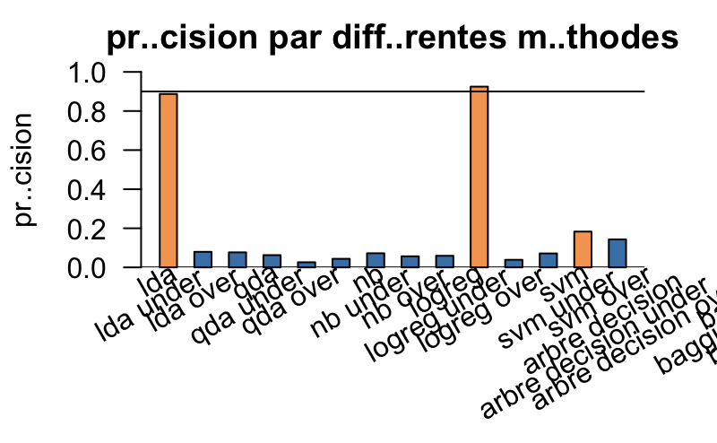

```r
abline(h=c(0,0.9))
```

```r
barplot(Performances_test$recall,col=c("sandybrown","steelblue","steelblue","steelblue","steelblue","steelblue","steelblue", "steelblue","steelblue","sandybrown","steelblue","steelblue","sandybrown","steelblue","steelblue","sandybrown","steelblue","steelblue","sandybrown","steelblue","steelblue","sandybrown","steelblue","steelblue"),
ylim=c(0,1),width=1,space=1,ylab="recall",las=1,main = "recall par différentes méthodes")
text(x=seq(2,48,by=2),y=-0.002, srt = 30, adj = 1.1, labels = models,xpd = TRUE)
```

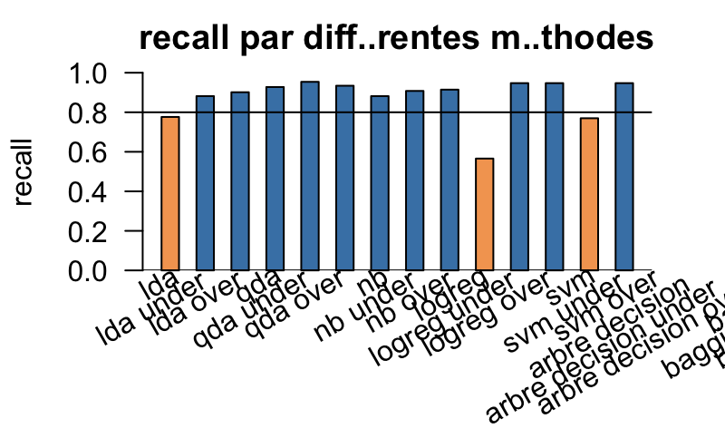

```r
abline(h=c(0,0.8))
```

```r
barplot(Performances_test$accuracy,col=c("sandybrown","steelblue","steelblue","steelblue","steelblue","steelblue","steelblue", "steelblue","steelblue","sandybrown","steelblue","steelblue","sandybrown","steelblue","steelblue","sandybrown","steelblue","steelblue","sandybrown","steelblue","steelblue","sandybrown","steelblue","steelblue"),
ylim=c(0,1),width=1,space=1,ylab="accuracy",las=1,main = "accuracy par différentes méthodes")
text(x=seq(2,46,by=2),y=-0.002, srt = 30, adj = 1.1, labels = models,xpd = TRUE)
```

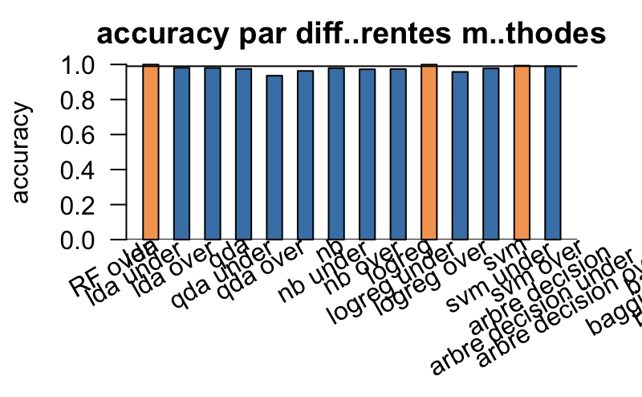

```r
abline(h=c(0,0.99))
```